Tarea 7 - Analisis Exploratorio

Por: César Omar López Arteaga

Marzo 2024

# PREGUNTA 1

Bajar los archivos Linnerud, Iris y Decathlon completo.

**Solucion**

Se descargara el archivo Linnerud.csv a una carpeta local, luego se cargara el archivo y se mostrara la estructura de la data, la cual llamaremos **“linne”**, luego se muestra la tabla con las primeras 10 observaciones.

```r
# Carga de la data Iris
linne<- read.csv("G:/R IMCA/TAREA 7/DESCARGA_DATA/Linnerud.csv",header=TRUE,row.names=1)

# Verificar la estructura de los datos
str(linne)
```

```
## 'data.frame':    20 obs. of  6 variables:
##  $ Peso        : int  191 189 193 162 189 182 211 167 176 154 ...
##  $ Cintura     : int  36 37 38 35 35 36 38 34 31 33 ...
##  $ Pulsaciones : int  50 52 58 62 46 56 56 60 74 56 ...
##  $ Lanzamientos: int  5 2 12 12 13 4 8 6 15 17 ...
##  $ Flexiones   : int  162 110 101 105 155 101 101 125 200 251 ...
##  $ Saltos      : int  60 60 101 37 58 42 38 40 40 250 ...
```

```r
# Visualizar los primeros registros de los datos sin modificar
head(linne,n=10)
```

|  | Peso | Cintura | Pulsaciones | Lanzamientos | Flexiones | Saltos |
| --- | --- | --- | --- | --- | --- | --- |
| 1 | 191 | 36 | 50 | 5 | 162 | 60 |
| 2 | 189 | 37 | 52 | 2 | 110 | 60 |
| 3 | 193 | 38 | 58 | 12 | 101 | 101 |
| 4 | 162 | 35 | 62 | 12 | 105 | 37 |
| 5 | 189 | 35 | 46 | 13 | 155 | 58 |
| 6 | 182 | 36 | 56 | 4 | 101 | 42 |
| 7 | 211 | 38 | 56 | 8 | 101 | 38 |
| 8 | 167 | 34 | 60 | 6 | 125 | 40 |
| 9 | 176 | 31 | 74 | 15 | 200 | 40 |
| 10 | 154 | 33 | 56 | 17 | 251 | 250 |

Se descargara el archivo Iris.csv a una carpeta local, luego se cargara el archivo y se mostrara la estructura de la data, la cual llamaremos **“iris”**, luego se muestra la tabla con las primeras 10 observaciones.

```r
# Carga de la data Iris
iris<- read.csv("G:/R IMCA/TAREA 7/DESCARGA_DATA/Iris.csv",header=TRUE,row.names=1)

# Verificar la estructura de los datos
str(iris)
```

```
## 'data.frame':    150 obs. of  5 variables:
##  $ Sepal.length: num  5.1 4.9 4.7 4.6 5 5.4 4.6 5 4.4 4.9 ...
##  $ Sepal.width : num  3.5 3 3.2 3.1 3.6 3.9 3.4 3.4 2.9 3.1 ...
##  $ Petal.length: num  1.4 1.4 1.3 1.5 1.4 1.7 1.4 1.5 1.4 1.5 ...
##  $ Petal.width : num  0.2 0.2 0.2 0.2 0.2 0.4 0.3 0.2 0.2 0.1 ...
##  $ Species     : chr  "setosa" "setosa" "setosa" "setosa" ...
```

```r
# Visualizar los primeros registros de los datos sin modificar
head(iris,n=10)
```

|  | Sepal.length | Sepal.width | Petal.length | Petal.width | Species |
| --- | --- | --- | --- | --- | --- |
| 1 | 5.1 | 3.5 | 1.4 | 0.2 | setosa |
| 2 | 4.9 | 3.0 | 1.4 | 0.2 | setosa |
| 3 | 4.7 | 3.2 | 1.3 | 0.2 | setosa |
| 4 | 4.6 | 3.1 | 1.5 | 0.2 | setosa |
| 5 | 5.0 | 3.6 | 1.4 | 0.2 | setosa |
| 6 | 5.4 | 3.9 | 1.7 | 0.4 | setosa |
| 7 | 4.6 | 3.4 | 1.4 | 0.3 | setosa |
| 8 | 5.0 | 3.4 | 1.5 | 0.2 | setosa |
| 9 | 4.4 | 2.9 | 1.4 | 0.2 | setosa |
| 10 | 4.9 | 3.1 | 1.5 | 0.1 | setosa |

Se descargara el archivo Decathlon_cpl.csv a una carpeta local, luego se cargara el archivo y se mostrara la estructura de la data, la cual llamaremos **“deca”**, luego se muestra la tabla con las primeras 10 observaciones.

```r
# Carga de la data Iris
deca<- read.csv("G:/R IMCA/TAREA 7/DESCARGA_DATA/Decathlon_cpl.csv",header=TRUE,row.names=1)

# Verificar la estructura de los datos
str(deca)
```

```
## 'data.frame':    41 obs. of  13 variables:
##  $ X100m       : num  11 10.8 11 11 11.3 ...
##  $ Long.jump   : num  7.58 7.4 7.3 7.23 7.09 7.6 7.3 7.31 6.81 7.56 ...
##  $ Shot.put    : num  14.8 14.3 14.8 14.2 15.2 ...
##  $ High.jump   : num  2.07 1.86 2.04 1.92 2.1 1.98 2.01 2.13 1.95 1.86 ...
##  $ X400m       : num  49.8 49.4 48.4 48.9 50.4 ...
##  $ X110m.hurdle: num  14.7 14.1 14.1 15 15.3 ...
##  $ Discus      : num  43.8 50.7 49 40.9 46.3 ...
##  $ Pole.vault  : num  5.02 4.92 4.92 5.32 4.72 4.92 4.42 4.42 4.92 4.82 ...
##  $ Javeline    : num  63.2 60.1 50.3 62.8 63.4 ...
##  $ X1500m      : num  292 302 300 280 276 ...
##  $ Rank        : int  1 2 3 4 5 6 7 8 9 10 ...
##  $ Points      : int  8217 8122 8099 8067 8036 8030 8004 7995 7802 7733 ...
##  $ Competition : chr  "Decastar" "Decastar" "Decastar" "Decastar" ...
```

```r
# Visualizar los primeros registros de los datos sin modificar
head(deca,n=10)
```

|  | X100m | Long.jump | Shot.put | High.jump | X400m | X110m.hurdle | Discus | Pole.vault | Javeline | X1500m | Rank | Points | Competition |
| --- | --- | --- | --- | --- | --- | --- | --- | --- | --- | --- | --- | --- | --- |
| SEBRLE | 11.04 | 7.58 | 14.83 | 2.07 | 49.81 | 14.69 | 43.75 | 5.02 | 63.19 | 291.7 | 1 | 8217 | Decastar |
| CLAY | 10.76 | 7.40 | 14.26 | 1.86 | 49.37 | 14.05 | 50.72 | 4.92 | 60.15 | 301.5 | 2 | 8122 | Decastar |
| KARPOV | 11.02 | 7.30 | 14.77 | 2.04 | 48.37 | 14.09 | 48.95 | 4.92 | 50.31 | 300.2 | 3 | 8099 | Decastar |
| BERNARD | 11.02 | 7.23 | 14.25 | 1.92 | 48.93 | 14.99 | 40.87 | 5.32 | 62.77 | 280.1 | 4 | 8067 | Decastar |
| YURKOV | 11.34 | 7.09 | 15.19 | 2.10 | 50.42 | 15.31 | 46.26 | 4.72 | 63.44 | 276.4 | 5 | 8036 | Decastar |
| WARNERS | 11.11 | 7.60 | 14.31 | 1.98 | 48.68 | 14.23 | 41.10 | 4.92 | 51.77 | 278.1 | 6 | 8030 | Decastar |
| ZSIVOCZKY | 11.13 | 7.30 | 13.48 | 2.01 | 48.62 | 14.17 | 45.67 | 4.42 | 55.37 | 268.0 | 7 | 8004 | Decastar |
| McMULLEN | 10.83 | 7.31 | 13.76 | 2.13 | 49.91 | 14.38 | 44.41 | 4.42 | 56.37 | 285.1 | 8 | 7995 | Decastar |
| MARTINEAU | 11.64 | 6.81 | 14.57 | 1.95 | 50.14 | 14.93 | 47.60 | 4.92 | 52.33 | 262.1 | 9 | 7802 | Decastar |
| HERNU | 11.37 | 7.56 | 14.41 | 1.86 | 51.10 | 15.06 | 44.99 | 4.82 | 57.19 | 285.1 | 10 | 7733 | Decastar |

# PREGUNTA 2

Calcular las tres matrices de correlacion (limitadamente a las variables cuantitativas): comentar en cada archivo las correlaciones mas bajas (negativas) y las mas altas.

**Solucion**

Se hara los calculos para la matriz de correlacion para los tres conjuntos de datos de la pregunta 1.

**PARA LA DATA LINNERUD**

De la matrix de correlacion de las variables Linnerud, vemos que las variable con mayor correlacion son:

- Peso - Cintura con r=0.8702435
- Lanzamientos - Flexiones con r=0.6957274

De la matrix de correlacion vemos que las variable con menor correlacion son:

- Flexiones - Cintura con r=-0.6455980
- Lanzamientos - Cintura con r=-0.5522321

```r
#Calculo de correlacion de toda la tabla, cruzando variables
cor(linne[,1:6])
```

```
##                    Peso    Cintura Pulsaciones Lanzamientos  Flexiones
## Peso          1.0000000  0.8702435 -0.36576203   -0.3896937 -0.4930836
## Cintura       0.8702435  1.0000000 -0.35289213   -0.5522321 -0.6455980
## Pulsaciones  -0.3657620 -0.3528921  1.00000000    0.1506480  0.2250381
## Lanzamientos -0.3896937 -0.5522321  0.15064802    1.0000000  0.6957274
## Flexiones    -0.4930836 -0.6455980  0.22503808    0.6957274  1.0000000
## Saltos       -0.2262956 -0.1914994  0.03493306    0.4957602  0.6692061
##                   Saltos
## Peso         -0.22629556
## Cintura      -0.19149937
## Pulsaciones   0.03493306
## Lanzamientos  0.49576018
## Flexiones     0.66920608
## Saltos        1.00000000
```

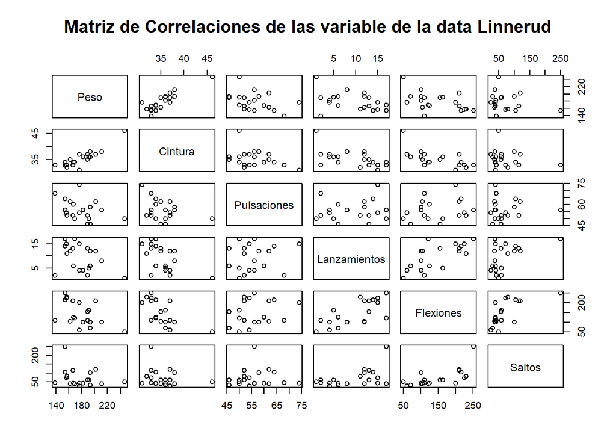

```r
#Matriz de Correlaciones total
plot(linne[,1:6], main="Matriz de Correlaciones de las variable de la data Linnerud")
```

Se graficara primero las relaciones de correlacion maximas las cuales son:

- [1] Peso - Cintura
- [2] Lanzamientos - Flexiones

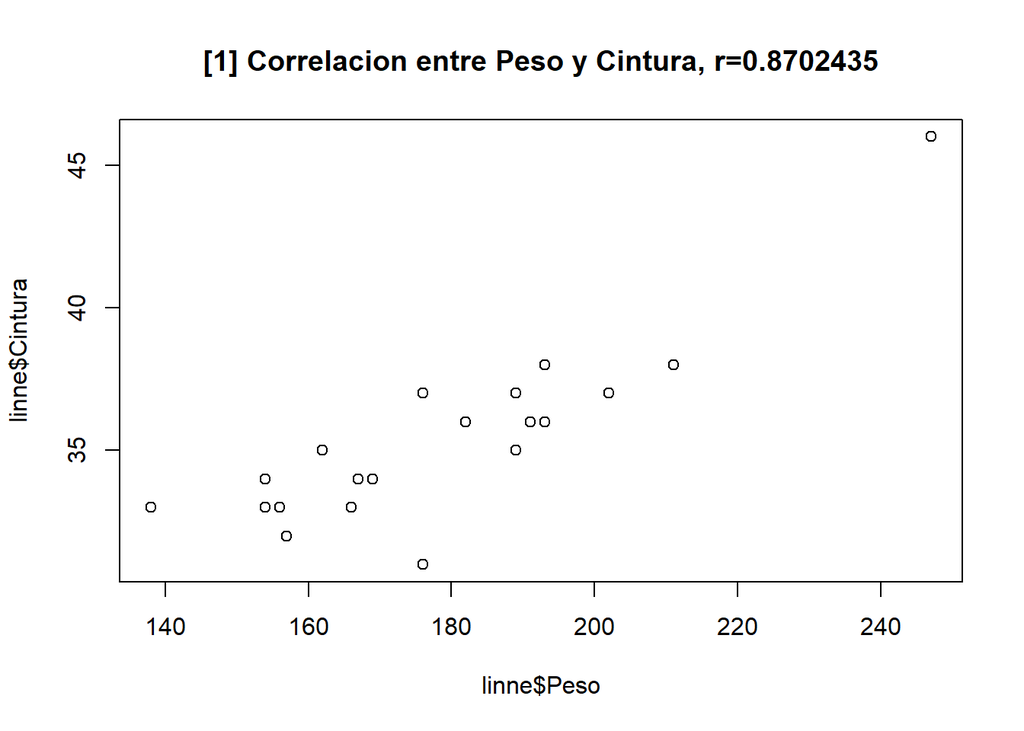

```r
#Correlacion entre Peso y Cintura
plot(linne$Peso,linne$Cintura,main="[1] Correlacion entre Peso y Cintura, r=0.8702435")
```

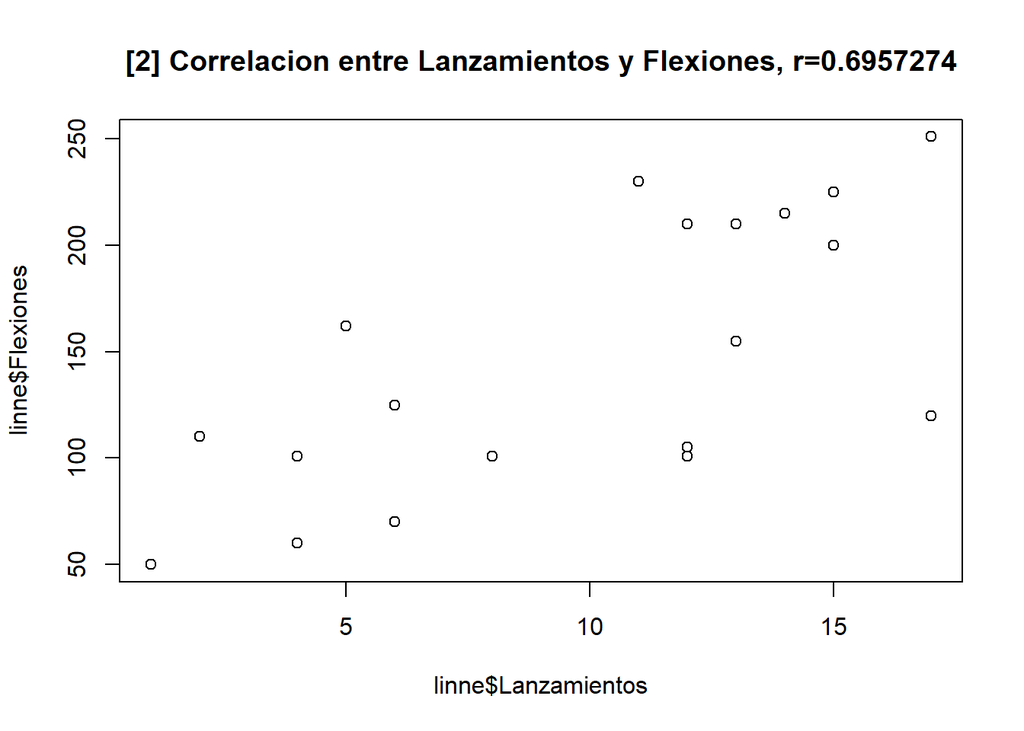

```r
#Correlacion entre Lanzamientos y Flexiones
plot(linne$Lanzamientos,linne$Flexiones,main="[2] Correlacion entre Lanzamientos y Flexiones, r=0.6957274")
```

Se graficara las relaciones de correlacion minimas las cuales son:

- [4] Flexiones - Cintura
- [5] Lanzamientos - Cintura

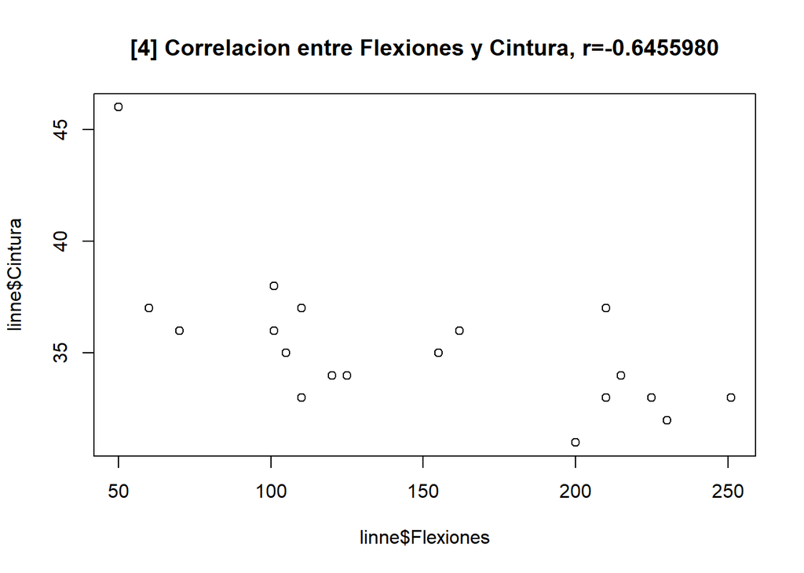

```r
#Correlacion entre Saltos y Pulsaciones
plot(linne$Flexiones,linne$Cintura,main="[4] Correlacion entre Flexiones y Cintura, r=-0.6455980")
```